# Dreem Project : Slow Oscillation Prediction

```python
from sklearn.ensemble import RandomForestClassifier
import pandas as pd
import h5py
import numpy as np
from sklearn.metrics import accuracy_score
from sklearn.model_selection import train_test_split
import xgboost as xgb
import matplotlib.pyplot as plt
import scipy
import pywt
from collections import Counter
from plotly import tools
from plotly.offline import init_notebook_mode, iplot, plot
import cufflinks as cf
import plotly.graph_objs as go
from datetime import datetime
from datetime import timedelta
import warnings
import time
warnings.filterwarnings('ignore')
```

## 1) Data Collection and pre-processing

```python
root_path = ""
```

```python
y_train = pd.read_csv(root_path + "y_train.csv").as_matrix()[:, 1].squeeze()
X_train = h5py.File(root_path + "X_train.h5", "r")
df_train = pd.DataFrame(data=X_train["features"][:])
```

### a) Labeling columns

```python
def label_columns(df):

    l_columns = ['num_pso',
             'mean_amp_pso',
             'mean_dur_pso',
              'amp_cso',
              'dur_cso',
              'curr_sleep_stage',
              'time_since_sleep',
              'time_in_ds',
              'time_in_ls',
              'time_in_rs',
              'time_in_ws']
    for i in range(12, 1261+1):
        l_columns.append('eeg_signal_%s'%(i-12+1))
    df.columns = l_columns

    return df
```

```python
label_columns(df_train)
```

|  | num_pso | mean_amp_pso | mean_dur_pso | amp_cso | dur_cso | curr_sleep_stage | time_since_sleep | time_in_ds | time_in_ls | time_in_rs | ... | eeg_signal_1241 | eeg_signal_1242 | eeg_signal_1243 | eeg_signal_1244 | eeg_signal_1245 | eeg_signal_1246 | eeg_signal_1247 | eeg_signal_1248 | eeg_signal_1249 | eeg_signal_1250 |
| --- | --- | --- | --- | --- | --- | --- | --- | --- | --- | --- | --- | --- | --- | --- | --- | --- | --- | --- | --- | --- | --- |
| 0 | 237.0 | 152.658761 | 341.523207 | 128.017491 | 429.0 | 3.0 | 11379.0 | 2730.0 | 3780.0 | 0.0 | ... | 22.707487 | 15.042639 | 9.706864 | 7.305480 | 5.344436 | 2.674903 | -0.055816 | -1.212385 | -2.461937 | -4.930397 |
| 1 | 176.0 | 146.883435 | 338.039773 | 119.130849 | 196.0 | 2.0 | 6721.0 | 2580.0 | 2100.0 | 0.0 | ... | 2.839801 | 3.458973 | 4.441102 | 3.975107 | 1.000240 | 2.870631 | 7.071897 | 7.848365 | 4.033517 | -2.110046 |
| 2 | 456.0 | 152.376541 | 335.629386 | 164.292580 | 417.0 | 2.0 | 26832.0 | 3240.0 | 7440.0 | 2130.0 | ... | 27.093293 | 22.821611 | 14.196937 | 5.708701 | -0.753271 | -5.627993 | -9.804085 | -12.863908 | -11.951175 | -5.531799 |
| 3 | 21.0 | 139.720772 | 336.285714 | 159.237082 | 407.0 | 3.0 | 1289.0 | 0.0 | 60.0 | 0.0 | ... | 28.191571 | 25.032295 | 17.296456 | 6.335396 | -4.008689 | -8.589818 | -5.876062 | 0.166707 | 6.054539 | 12.086351 |
| 4 | 72.0 | 140.649432 | 349.875000 | 130.184278 | 297.0 | 3.0 | 2262.0 | 630.0 | 960.0 | 0.0 | ... | -7.942308 | -10.407617 | -3.418883 | 9.222596 | 21.236168 | 28.245889 | 27.024864 | 17.794644 | 7.602379 | -4.548318 |
| 5 | 164.0 | 144.847843 | 337.237805 | 252.473489 | 394.0 | 2.0 | 6381.0 | 2580.0 | 1740.0 | 0.0 | ... | 0.382737 | 3.833959 | 6.645052 | 10.463593 | 13.190432 | 12.864986 | 9.890164 | 4.352373 | -1.054502 | -5.224108 |
| 6 | 260.0 | 152.699259 | 338.865385 | 215.023977 | 331.0 | 2.0 | 13614.0 | 2730.0 | 4470.0 | 0.0 | ... | 12.253284 | 14.861523 | 17.448599 | 19.673640 | 21.139325 | 20.590147 | 16.902844 | 9.947240 | 3.201194 | -3.086158 |
| 7 | 113.0 | 143.275214 | 346.601770 | 122.776337 | 297.0 | 3.0 | 3058.0 | 1860.0 | 960.0 | 0.0 | ... | 10.413213 | 11.558270 | 10.148593 | 5.652390 | 1.728300 | 1.746352 | 3.019379 | 2.473319 | 0.993924 | -1.379761 |
| 8 | 159.0 | 144.166783 | 337.245283 | 131.431768 | 314.0 | 2.0 | 6216.0 | 2580.0 | 1590.0 | 0.0 | ... | 19.468976 | 18.654257 | 17.580130 | 14.152408 | 7.379240 | -1.661259 | -7.683012 | -9.873958 | -11.299131 | -13.039043 |
| 9 | 31.0 | 139.709626 | 345.967742 | 126.789608 | 420.0 | 3.0 | 1511.0 | 0.0 | 360.0 | 0.0 | ... | 8.900036 | 16.335863 | 18.984523 | 16.972549 | 12.041149 | 1.502789 | -11.907635 | -20.536992 | -19.681660 | -11.282594 |
| 10 | 124.0 | 143.891555 | 347.330645 | 175.418830 | 437.0 | 2.0 | 5785.0 | 2190.0 | 960.0 | 0.0 | ... | 18.749614 | 19.456357 | 21.323322 | 20.328402 | 15.862704 | 8.108825 | 2.568996 | 4.160621 | 9.075842 | 10.314318 |
| 11 | 275.0 | 152.363521 | 339.803636 | 215.851947 | 301.0 | 2.0 | 14116.0 | 2730.0 | 4920.0 | 0.0 | ... | 12.512117 | 8.852669 | 8.013559 | 10.357791 | 12.473304 | 14.100068 | 12.363981 | 5.454522 | -4.547029 | -16.784072 |
| 12 | 424.0 | 152.510888 | 337.195755 | 144.301707 | 218.0 | 2.0 | 25365.0 | 3240.0 | 6660.0 | 2130.0 | ... | 19.724041 | 29.992770 | 35.478568 | 33.014115 | 21.510595 | 5.706921 | -12.060422 | -29.288402 | -39.896476 | -42.511032 |
| 13 | 306.0 | 150.230902 | 336.124183 | 201.399918 | 343.0 | 2.0 | 16340.0 | 2730.0 | 5310.0 | 510.0 | ... | 17.021544 | 13.281804 | 7.419093 | 2.249831 | -2.588662 | -8.157658 | -13.799398 | -17.077319 | -19.682838 | -23.587745 |
| 14 | 391.0 | 152.750298 | 338.322251 | 123.764104 | 448.0 | 2.0 | 24453.0 | 2910.0 | 6000.0 | 2130.0 | ... | 57.348318 | 53.837118 | 44.148970 | 23.974008 | -1.787396 | -23.758150 | -37.890038 | -49.813759 | -57.074149 | -58.227981 |
| 15 | 407.0 | 152.770543 | 338.921376 | 192.883924 | 362.0 | 2.0 | 25095.0 | 3240.0 | 6150.0 | 2130.0 | ... | 37.569203 | 37.065724 | 35.811948 | 32.226765 | 26.053433 | 19.989710 | 13.387354 | 3.375650 | -9.635604 | -20.645820 |
| 16 | 487.0 | 152.761630 | 336.392197 | 112.994860 | 272.0 | 2.0 | 33157.0 | 3240.0 | 8370.0 | 2130.0 | ... | 18.278836 | 20.547601 | 20.610684 | 22.130795 | 20.597820 | 15.356854 | 4.666055 | -7.906267 | -13.136806 | -7.470657 |
| 17 | 320.0 | 150.027284 | 334.606250 | 182.987109 | 163.0 | 2.0 | 16597.0 | 2730.0 | 5310.0 | 870.0 | ... | 7.862899 | 2.572525 | -4.568537 | -9.153823 | -10.862983 | -13.430944 | -16.830900 | -17.319222 | -15.576551 | -13.956774 |
| 18 | 233.0 | 151.821684 | 340.995708 | 270.062066 | 352.0 | 3.0 | 11009.0 | 2730.0 | 3660.0 | 0.0 | ... | 25.994621 | 16.941624 | 6.002818 | 1.155263 | 4.243462 | 12.004627 | 17.261293 | 16.740805 | 13.112485 | 10.103427 |
| 19 | 418.0 | 152.977908 | 338.528708 | 116.691871 | 284.0 | 2.0 | 25316.0 | 3240.0 | 6480.0 | 2130.0 | ... | 32.389092 | 23.029441 | 14.092987 | 8.038392 | 2.782477 | -2.869830 | -10.922157 | -20.438223 | -30.960150 | -42.042025 |
| 20 | 138.0 | 144.907484 | 345.260870 | 187.912468 | 347.0 | 2.0 | 5897.0 | 2310.0 | 1230.0 | 0.0 | ... | 17.921092 | 9.999664 | 7.080558 | 7.154536 | 7.695572 | 8.786030 | 10.073041 | 11.373262 | 13.875199 | 15.726193 |
| 21 | 55.0 | 140.184375 | 353.927273 | 136.812374 | 312.0 | 3.0 | 1983.0 | 120.0 | 960.0 | 0.0 | ... | 11.945018 | 14.316302 | 17.643038 | 20.287760 | 17.259547 | 9.903304 | 4.309604 | 0.483605 | -4.273277 | -9.346980 |
| 22 | 192.0 | 147.514637 | 338.067708 | 139.649434 | 312.0 | 2.0 | 7027.0 | 2580.0 | 2580.0 | 0.0 | ... | 17.364723 | 13.429541 | 11.812790 | 12.024307 | 10.108896 | 3.927185 | -7.334445 | -23.042962 | -37.061413 | -47.656441 |
| 23 | 213.0 | 149.607891 | 340.042254 | 127.696765 | 298.0 | 2.0 | 7571.0 | 2730.0 | 3060.0 | 0.0 | ... | 24.707096 | 11.098665 | 0.769369 | -3.824191 | -3.047309 | 0.168305 | 2.383306 | 2.931635 | 1.994677 | -0.482999 |
| 24 | 345.0 | 149.620453 | 335.179710 | 189.163359 | 404.0 | 2.0 | 17940.0 | 2730.0 | 5310.0 | 1620.0 | ... | 50.296154 | 40.219371 | 30.007865 | 17.261385 | 0.374123 | -16.772544 | -27.283847 | -26.659040 | -19.595461 | -12.627728 |
| 25 | 1.0 | 110.189807 | 350.000000 | 175.921276 | 272.0 | 2.0 | 322.0 | 0.0 | 0.0 | 0.0 | ... | 36.366172 | 34.137922 | 32.221215 | 25.586505 | 15.335394 | 4.580909 | -6.727545 | -15.526279 | -19.591836 | -19.178659 |
| 26 | 14.0 | 139.974511 | 334.214286 | 188.006519 | 335.0 | 3.0 | 1097.0 | 0.0 | 0.0 | 0.0 | ... | 22.881484 | 24.088507 | 23.522517 | 20.098377 | 13.442654 | 6.521397 | 1.552542 | -2.219959 | -3.143566 | -4.023184 |
| 27 | 224.0 | 149.310080 | 338.937500 | 115.488740 | 339.0 | 2.0 | 7930.0 | 2730.0 | 3390.0 | 0.0 | ... | 9.251564 | 11.268960 | 8.437246 | 1.697950 | -4.248086 | -7.213400 | -7.477935 | -4.813259 | -0.429105 | 2.919230 |
| 28 | 228.0 | 149.764492 | 338.767544 | 128.378169 | 469.0 | 2.0 | 10495.0 | 2730.0 | 3510.0 | 0.0 | ... | 35.683582 | 28.038546 | 15.908054 | 2.395465 | -6.677430 | -11.537660 | -15.599449 | -19.058547 | -17.556796 | -11.108955 |
| 29 | 152.0 | 145.000132 | 342.039474 | 127.328451 | 351.0 | 2.0 | 6024.0 | 2460.0 | 1500.0 | 0.0 | ... | 11.062412 | 12.789668 | 11.095091 | 9.699380 | 7.192242 | 2.624218 | 0.141306 | -0.422830 | 1.585465 | 0.118084 |
| ... | ... | ... | ... | ... | ... | ... | ... | ... | ... | ... | ... | ... | ... | ... | ... | ... | ... | ... | ... | ... | ... |
| 261604 | 167.0 | 160.671565 | 324.341317 | 193.283002 | 441.0 | 3.0 | 6895.0 | 2070.0 | 1440.0 | 0.0 | ... | 21.681165 | 22.683984 | 23.617092 | 21.022893 | 14.277772 | 7.376261 | -1.029417 | -11.948048 | -22.701265 | -30.018596 |
| 261605 | 429.0 | 161.004180 | 328.335664 | 180.224821 | 376.0 | 3.0 | 20701.0 | 3570.0 | 4710.0 | 2010.0 | ... | 12.474191 | 15.037756 | 16.640505 | 14.970631 | 11.262718 | 7.760451 | 5.663376 | 3.156795 | -0.703377 | -3.775470 |
| 261606 | 124.0 | 166.253609 | 331.588710 | 168.601037 | 339.0 | 2.0 | 3854.0 | 1740.0 | 810.0 | 0.0 | ... | 41.066760 | 36.400239 | 26.951780 | 15.843581 | 7.087521 | 0.390712 | -7.215731 | -16.227937 | -25.151607 | -29.747394 |
| 261607 | 407.0 | 160.794345 | 329.007371 | 228.411483 | 287.0 | 3.0 | 20470.0 | 3570.0 | 4710.0 | 1470.0 | ... | 18.549088 | 18.080934 | 16.415385 | 11.536861 | 6.554205 | 3.518907 | 4.989412 | 8.135140 | 8.733454 | 11.646113 |
| 261608 | 74.0 | 163.000175 | 336.689189 | 130.024557 | 419.0 | 3.0 | 1380.0 | 990.0 | 420.0 | 0.0 | ... | 20.043401 | 20.778947 | 18.874294 | 11.734696 | 5.166549 | 0.560258 | -1.377029 | 2.500000 | -3.535491 | -15.949601 |
| 261609 | 231.0 | 160.675471 | 327.363636 | 112.488077 | 321.0 | 3.0 | 7529.0 | 2070.0 | 2340.0 | 930.0 | ... | 25.061188 | 21.823352 | 13.807698 | 5.540645 | -1.873785 | -7.979904 | -11.190057 | -12.380939 | -14.005249 | -15.466301 |
| 261610 | 281.0 | 160.315032 | 327.597865 | 114.273854 | 225.0 | 2.0 | 8752.0 | 3300.0 | 2610.0 | 930.0 | ... | 7.109734 | 1.131376 | -5.367766 | -7.727695 | -4.313499 | 0.187883 | -1.099199 | -6.209143 | -10.371099 | -14.887450 |
| 261611 | 162.0 | 161.549641 | 325.141975 | 127.744609 | 251.0 | 3.0 | 6745.0 | 2070.0 | 1290.0 | 0.0 | ... | 9.643577 | 5.921981 | 5.588795 | 8.913943 | 10.890182 | 10.784373 | 9.214065 | 6.928942 | 1.452526 | -6.640812 |
| 261612 | 30.0 | 166.607097 | 334.833333 | 130.264842 | 393.0 | 3.0 | 1172.0 | 0.0 | 90.0 | 0.0 | ... | 12.422786 | 12.355096 | 10.332525 | 9.308382 | 10.529912 | 8.970591 | 2.037424 | -8.393974 | -21.608082 | -30.623410 |
| 261613 | 238.0 | 160.460676 | 327.399160 | 153.838437 | 285.0 | 3.0 | 7633.0 | 2070.0 | 2550.0 | 930.0 | ... | 9.063151 | 10.616447 | 12.392648 | 13.241276 | 12.873007 | 12.348945 | 13.162788 | 12.069041 | 9.666246 | 6.458298 |
| 261614 | 291.0 | 159.223831 | 326.756014 | 131.005716 | 212.0 | 2.0 | 10020.0 | 3570.0 | 2610.0 | 930.0 | ... | 23.375935 | 18.462130 | 14.263228 | 5.434273 | -6.075922 | -7.946327 | -0.673773 | -2.208910 | -7.282908 | -10.634965 |
| 261615 | 357.0 | 162.006996 | 330.347339 | 145.044031 | 460.0 | 2.0 | 19190.0 | 3570.0 | 3780.0 | 930.0 | ... | 4.822425 | 9.562309 | 10.931421 | 6.886047 | 5.213459 | 5.845483 | 4.448243 | 3.678685 | 0.229994 | -5.173218 |
| 261616 | 411.0 | 160.985006 | 328.783455 | 171.617835 | 326.0 | 3.0 | 20499.0 | 3570.0 | 4710.0 | 1590.0 | ... | 23.660213 | 23.449020 | 20.523880 | 14.604664 | 7.239784 | 0.308811 | -3.101018 | -2.999234 | -0.561000 | 1.044516 |
| 261617 | 226.0 | 160.115079 | 325.115044 | 220.810206 | 437.0 | 3.0 | 7497.0 | 2070.0 | 2190.0 | 930.0 | ... | 26.071122 | 24.017387 | 18.212648 | 7.019845 | -4.128440 | -12.990150 | -18.630961 | -20.235267 | -17.786017 | -12.659438 |
| 261618 | 179.0 | 160.040653 | 323.910615 | 228.339809 | 359.0 | 3.0 | 7088.0 | 2070.0 | 1470.0 | 330.0 | ... | 34.184958 | 27.955980 | 22.052184 | 16.336163 | 10.325666 | 6.504229 | 4.936613 | 1.733998 | -4.017233 | -10.407942 |
| 261619 | 29.0 | 166.345868 | 336.965517 | 174.182738 | 273.0 | 3.0 | 1112.0 | 0.0 | 60.0 | 0.0 | ... | 35.390991 | 29.125941 | 20.430171 | 15.933567 | 10.802396 | 0.586398 | -4.267752 | -10.098644 | -19.372817 | -24.572270 |
| 261620 | 384.0 | 161.483276 | 329.664062 | 129.222743 | 406.0 | 3.0 | 20201.0 | 3570.0 | 4560.0 | 930.0 | ... | 12.632840 | 12.800713 | 9.463207 | 8.481666 | 6.235185 | 1.244048 | -3.286148 | -4.677924 | -7.162494 | -11.440851 |
| 261621 | 284.0 | 159.978812 | 326.598592 | 111.346121 | 369.0 | 2.0 | 8916.0 | 3390.0 | 2610.0 | 930.0 | ... | 14.499086 | 16.790321 | 17.320732 | 16.100707 | 10.417601 | 3.157544 | -2.674891 | -7.546780 | -11.334044 | -15.512888 |
| 261622 | 263.0 | 159.699902 | 326.901141 | 137.233363 | 305.0 | 3.0 | 7822.0 | 2760.0 | 2610.0 | 930.0 | ... | 19.150716 | 17.658956 | 16.369784 | 14.168488 | 9.095177 | 5.581983 | 5.350796 | 4.905414 | 3.243098 | 1.790086 |
| 261623 | 5.0 | 172.829312 | 360.800000 | 181.401522 | 375.0 | 3.0 | 738.0 | 0.0 | 0.0 | 0.0 | ... | 47.772923 | 27.240202 | 2.920509 | -15.098881 | -33.268399 | -43.963377 | -45.123570 | -50.615646 | -56.169954 | -50.957678 |
| 261624 | 316.0 | 159.293638 | 325.098101 | 155.901154 | 219.0 | 2.0 | 12949.0 | 3570.0 | 2820.0 | 930.0 | ... | 18.713732 | 17.232776 | 18.283436 | 19.638559 | 16.917618 | 9.562541 | 0.304604 | -11.221016 | -23.513447 | -32.546980 |
| 261625 | 365.0 | 161.612382 | 330.183562 | 200.896185 | 314.0 | 2.0 | 19480.0 | 3570.0 | 3990.0 | 930.0 | ... | 17.963221 | 17.754082 | 17.567041 | 17.561231 | 14.915362 | 10.600382 | 9.007566 | 7.276438 | 7.140149 | 7.897613 |
| 261626 | 339.0 | 161.772375 | 328.766962 | 225.377996 | 394.0 | 2.0 | 17143.0 | 3570.0 | 3390.0 | 930.0 | ... | 32.363710 | 28.246034 | 22.716523 | 19.848911 | 17.696327 | 12.645497 | 6.464860 | 0.815282 | -6.834274 | -10.235247 |
| 261627 | 450.0 | 160.477041 | 329.284444 | 116.492047 | 216.0 | 3.0 | 20865.0 | 3570.0 | 5310.0 | 2040.0 | ... | 13.049329 | 9.519638 | 6.924249 | 4.691172 | 3.797351 | 3.326524 | 1.677413 | -2.277960 | -6.649806 | -9.118434 |
| 261628 | 271.0 | 159.686748 | 327.040590 | 293.475438 | 269.0 | 3.0 | 7849.0 | 3000.0 | 2610.0 | 930.0 | ... | 39.713499 | 27.158197 | 13.240311 | -0.259060 | -10.069181 | -14.985047 | -17.241020 | -18.092463 | -19.342412 | -21.391293 |
| 261629 | 360.0 | 161.802964 | 331.100000 | 141.336652 | 340.0 | 2.0 | 19325.0 | 3570.0 | 3840.0 | 930.0 | ... | 13.065583 | 9.434950 | 9.473221 | 12.065106 | 13.698066 | 13.855282 | 6.129222 | -6.950655 | -20.657118 | -29.779900 |
| 261630 | 56.0 | 163.308536 | 334.232143 | 163.062138 | 467.0 | 3.0 | 1311.0 | 450.0 | 420.0 | 0.0 | ... | 42.310400 | 28.315092 | 14.786182 | 5.273041 | -2.463138 | -11.723685 | -19.440888 | -23.864136 | -23.833840 | -27.395720 |
| 261631 | 403.0 | 161.133023 | 329.992556 | 128.337980 | 137.0 | 3.0 | 20457.0 | 3570.0 | 4710.0 | 1350.0 | ... | 12.218106 | 9.973872 | 5.976524 | -1.373121 | -11.866239 | -20.257274 | -23.825623 | -25.191771 | -25.347591 | -24.884717 |
| 261632 | 4.0 | 177.998984 | 356.750000 | 152.150624 | 377.0 | 2.0 | 233.0 | 0.0 | 0.0 | 0.0 | ... | 21.529737 | 18.232119 | 15.866710 | 12.480715 | 9.386753 | 5.762247 | -3.450520 | -8.088882 | -6.258801 | -7.519336 |
| 261633 | 203.0 | 159.629057 | 324.960591 | 139.453465 | 341.0 | 3.0 | 7313.0 | 2070.0 | 1560.0 | 930.0 | ... | -4.347014 | -10.772180 | -11.712714 | -7.343330 | -1.962082 | 2.393410 | 5.491454 | 7.212352 | 9.378788 | 7.871285 |

261634 rows × 1261 columns

## 2) Data Visualization & Exploration

### a) Visualization of various EEG signals

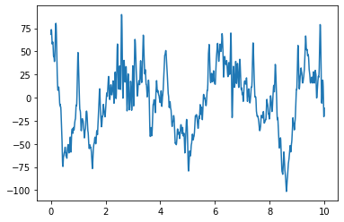

```python
df_signal = df_train.loc[:, 'eeg_signal_1':'eeg_signal_1250']
t = np.linspace(0,10,1250)
plt.plot(t,df_signal.iloc[9,:])
```

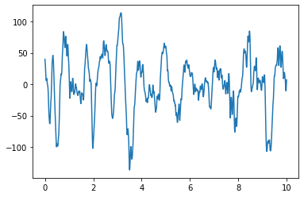

```python
plt.plot(t,df_signal.iloc[56323,:])
```

### b) Distribution of classes for phases 2 and 3

**This exploration between patients in NREM2 and NREM3 is motivated by the different physical properties of these two stages**

```python
df_count = df_train_final.copy()
df_count.groupby(['curr_sleep_stage_2.0'])[var_to_pred].value_counts() #more 0s for phase 2 and more 1s and 2s for phase 3
```

```
curr_sleep_stage_2.0  SO
0                     1     47982
                      2     44361
                      0     37925
1                     0     76107
                      1     30638
                      2     24621
Name: SO, dtype: int64
```

**Indeed, we observe that in NREM2, you are more lucky to not have any slow oscillation in the next second compared to NREM3**

## 3) Data Engineering

### a) Adding base features (mean, max, min)

```python
def extract_features_base(df):

    #compute new columns
    df["mean"] = np.mean(df.loc[:, 'eeg_signal_1':],axis=1)
    df["min"] = np.min(df.loc[:, 'eeg_signal_1':],axis=1)
    df["max"] = np.max(df.loc[:, 'eeg_signal_1':],axis=1)

    #extract columns
    df_final = df.loc[:, :'time_in_ws']
    df_final["mean"] = df.loc[:,"mean"]
    df_final["max"] = df.loc[:,"max"]
    df_final["min"] = df.loc[:,"min"]

    return df_final

df_train_final = extract_features_base(df_train)
```

```python
df_train_final.head()
```

|  | num_pso | mean_amp_pso | mean_dur_pso | amp_cso | dur_cso | curr_sleep_stage | time_since_sleep | time_in_ds | time_in_ls | time_in_rs | time_in_ws | mean | max | min |
| --- | --- | --- | --- | --- | --- | --- | --- | --- | --- | --- | --- | --- | --- | --- |
| 0 | 237.0 | 152.658761 | 341.523207 | 128.017491 | 429.0 | 3.0 | 11379.0 | 2730.0 | 3780.0 | 0.0 | 480.0 | 11.409497 | 211.599465 | -258.301643 |
| 1 | 176.0 | 146.883435 | 338.039773 | 119.130849 | 196.0 | 2.0 | 6721.0 | 2580.0 | 2100.0 | 0.0 | 480.0 | -1.222639 | 70.103670 | -97.923331 |
| 2 | 456.0 | 152.376541 | 335.629386 | 164.292580 | 417.0 | 2.0 | 26832.0 | 3240.0 | 7440.0 | 2130.0 | 750.0 | 3.547349 | 117.154570 | -121.882075 |
| 3 | 21.0 | 139.720772 | 336.285714 | 159.237082 | 407.0 | 3.0 | 1289.0 | 0.0 | 60.0 | 0.0 | 450.0 | -0.119429 | 92.368167 | -110.453401 |
| 4 | 72.0 | 140.649432 | 349.875000 | 130.184278 | 297.0 | 3.0 | 2262.0 | 630.0 | 960.0 | 0.0 | 450.0 | 1.421637 | 105.522241 | -119.812297 |

### b) Adding Entropy's variables (using Raphael Vallat's package)

```python
from entropy import *

df_train_final["perm_entropy"] = df_train.loc[:, 'eeg_signal_1':].apply(lambda x: perm_entropy(x, order=3, normalize=True), axis=1)
df_train_final["svd_entropy"] = df_train.loc[:, 'eeg_signal_1':].apply(lambda x: svd_entropy(x, order=3, delay=1, normalize=True), axis=1)
df_train_final["higuchi_fd"] = df_train.loc[:, 'eeg_signal_1':].apply(lambda x: higuchi_fd(x, kmax=10), axis=1)
df_train_final["detrended_fluctuation"] = df_train.loc[:, 'eeg_signal_1':].apply(lambda x: detrended_fluctuation(x), axis=1)
```

```python
df_train_final.head()
```

|  | num_pso | mean_amp_pso | mean_dur_pso | amp_cso | dur_cso | curr_sleep_stage | time_since_sleep | time_in_ds | time_in_ls | time_in_rs | time_in_ws | mean | max | min | perm_entropy | svd_entropy | higuchi_fd | detrended_fluctuation |
| --- | --- | --- | --- | --- | --- | --- | --- | --- | --- | --- | --- | --- | --- | --- | --- | --- | --- | --- |
| 0 | 237.0 | 152.658761 | 341.523207 | 128.017491 | 429.0 | 3.0 | 11379.0 | 2730.0 | 3780.0 | 0.0 | 480.0 | 11.409497 | 211.599465 | -258.301643 | 0.728267 | 0.342592 | 1.275086 | 1.678507 |
| 1 | 176.0 | 146.883435 | 338.039773 | 119.130849 | 196.0 | 2.0 | 6721.0 | 2580.0 | 2100.0 | 0.0 | 480.0 | -1.222639 | 70.103670 | -97.923331 | 0.756092 | 0.535558 | 1.377621 | 1.445956 |
| 2 | 456.0 | 152.376541 | 335.629386 | 164.292580 | 417.0 | 2.0 | 26832.0 | 3240.0 | 7440.0 | 2130.0 | 750.0 | 3.547349 | 117.154570 | -121.882075 | 0.774415 | 0.402331 | 1.403614 | 1.548072 |
| 3 | 21.0 | 139.720772 | 336.285714 | 159.237082 | 407.0 | 3.0 | 1289.0 | 0.0 | 60.0 | 0.0 | 450.0 | -0.119429 | 92.368167 | -110.453401 | 0.733231 | 0.483922 | 1.335530 | 1.430026 |
| 4 | 72.0 | 140.649432 | 349.875000 | 130.184278 | 297.0 | 3.0 | 2262.0 | 630.0 | 960.0 | 0.0 | 450.0 | 1.421637 | 105.522241 | -119.812297 | 0.764846 | 0.446307 | 1.354167 | 1.497231 |

### c) Adding Fourrier decomposition using FFT

```python
n_fft = 64
newcolumns = ['fft_%s'%(i) for i in range(0,n_fft)]
df_train_final[newcolumns] = df_train.loc[:, 'eeg_signal_1':].apply(lambda x: pd.Series(np.abs(np.fft.fft(x, n=n_fft, axis=-1, norm=None))), axis=1)
```

```python
df_train_final.head()
```

|  | num_pso | mean_amp_pso | mean_dur_pso | amp_cso | dur_cso | curr_sleep_stage | time_since_sleep | time_in_ds | time_in_ls | time_in_rs | time_in_ws | mean | max | min | perm_entropy | svd_entropy | higuchi_fd | detrended_fluctuation | fft_0 | fft_1 | fft_2 | fft_3 | fft_4 | fft_5 | fft_6 | fft_7 | fft_8 | fft_9 | fft_10 | … |
| --- | --- | --- | --- | --- | --- | --- | --- | --- | --- | --- | --- | --- | --- | --- | --- | --- | --- | --- | --- | --- | --- | --- | --- | --- | --- | --- | --- | --- | --- | --- |
| 0 | 237.0 | 152.658761 | 341.523207 | 128.017491 | 429.0 | 3.0 | 11379.0 | 2730.0 | 3780.0 | 0.0 | 480.0 | 11.409497 | 211.599465 | -258.301643 | 0.728267 | 0.342592 | 1.275086 | 1.678507 | 8949.191326 | 2881.469101 | 1202.252894 | 897.478162 | 611.400833 | 581.554347 | 362.213072 | 414.566139 | 255.368381 | 296.043320 | 288.175853 | … |
| 1 | 176.0 | 146.883435 | 338.039773 | 119.130849 | 196.0 | 2.0 | 6721.0 | 2580.0 | 2100.0 | 0.0 | 480.0 | -1.222639 | 70.103670 | -97.923331 | 0.756092 | 0.535558 | 1.377621 | 1.445956 | 466.097649 | 95.512874 | 128.319558 | 128.155812 | 88.206012 | 152.899871 | 156.173110 | 80.240111 | 36.995098 | 25.500161 | 72.552743 | … |
| 2 | 456.0 | 152.376541 | 335.629386 | 164.292580 | 417.0 | 2.0 | 26832.0 | 3240.0 | 7440.0 | 2130.0 | 750.0 | 3.547349 | 117.154570 | -121.882075 | 0.774415 | 0.402331 | 1.403614 | 1.548072 | 109.219271 | 421.929496 | 73.321368 | 145.931487 | 117.260408 | 142.596567 | 191.538389 | 95.946193 | 72.954328 | 41.753858 | 82.851058 | … |
| 3 | 21.0 | 139.720772 | 336.285714 | 159.237082 | 407.0 | 3.0 | 1289.0 | 0.0 | 60.0 | 0.0 | 450.0 | -0.119429 | 92.368167 | -110.453401 | 0.733231 | 0.483922 | 1.335530 | 1.430026 | 1115.678852 | 502.726750 | 561.917518 | 469.225618 | 237.854640 | 229.645919 | 101.155184 | 53.049434 | 29.843358 | 42.161239 | 4.523127 | … |
| 4 | 72.0 | 140.649432 | 349.875000 | 130.184278 | 297.0 | 3.0 | 2262.0 | 630.0 | 960.0 | 0.0 | 450.0 | 1.421637 | 105.522241 | -119.812297 | 0.764846 | 0.446307 | 1.354167 | 1.497231 | 1924.900276 | 995.418749 | 917.724400 | 697.254169 | 215.149291 | 334.536511 | 245.793100 | 119.126821 | 181.139463 | 97.758306 | 136.957713 | … |

5 rows × 82 columns

### d) Adding Discrete Wawelet Transformation

```python
def calculate_entropy(list_values):
    counter_values = Counter(list_values).most_common()
    probabilities = [elem[1]/len(list_values) for elem in counter_values]
    entropy = scipy.stats.entropy(probabilities)
    return entropy

def calculate_statistics(list_values):
    n5 = np.nanpercentile(list_values, 5)
    n25 = np.nanpercentile(list_values, 25)
    n75 = np.nanpercentile(list_values, 75)
    n95 = np.nanpercentile(list_values, 95)
    median = np.nanpercentile(list_values, 50)
    mean = np.nanmean(list_values)
    std = np.nanstd(list_values)
    var = np.nanvar(list_values)
    rms = np.nanmean(np.sqrt(list_values**2))
    return [n5, n25, n75, n95, median, mean, std, var, rms]

def calculate_crossings(list_values):
    zero_crossing_indices = np.nonzero(np.diff(np.array(list_values) > 0))[0]
    no_zero_crossings = len(zero_crossing_indices)
    mean_crossing_indices = np.nonzero(np.diff(np.array(list_values) > np.nanmean(list_values)))[0]
    no_mean_crossings = len(mean_crossing_indices)
    return [no_zero_crossings, no_mean_crossings]

def get_features(list_values):
    entropy = calculate_entropy(list_values)
    crossings = calculate_crossings(list_values)
    statistics = calculate_statistics(list_values)
    return [entropy] + crossings + statistics

def get_wawelet_features(dataset, waveletname):
    wawelet_features = []
    for signal_no in range(0, len(dataset)):
        features = []
        signal = dataset.loc[signal_no, :]
        list_coeff = pywt.wavedec(signal, waveletname)
        for coeff in list_coeff:
            features += get_features(coeff)

        wawelet_features.append(features)
    X = pd.DataFrame(wawelet_features)
    waweletscolumns = ['wawelets_%s'%(i) for i in range(0, 96)]
    X.columns=waweletscolumns
    return X
```

```python
wawelets = get_wawelet_features(df_train.loc[:, 'eeg_signal_1':'eeg_signal_1250'],"db5")
df_train_final = pd.concat([df_train_final,wawelets],axis=1)
```

### e) Adding dummies for sleep stages

```python
df_train_final = pd.get_dummies(df_train_final, prefix=['curr_sleep_stage'], columns=['curr_sleep_stage'])
```

### f) Adding outcome variable in the dataframe

```python
var_to_pred = 'SO'
y_train = pd.DataFrame(y_train, columns=[var_to_pred], index=df_train.index) #!important to keep same index
df_train_final[var_to_pred] = y_train[var_to_pred]
```

### g) Adding Spindle detection using YASA package

```python
import yasa
import logging
logging.getLogger("imported_module").setLevel(logging.ERROR)

sf = 125.
data = df_train.loc[:, 'eeg_signal_1':]
df_train_final['spindles'] = data.apply(lambda x: 1 if isinstance(yasa.spindles_detect(x, sf), pd.DataFrame) else 0, axis=1)
sp = yasa.spindles_detect(data.loc[1], sf)
sp
```

|  | Start | End | Duration | Amplitude | RMS | AbsPower | RelPower | Frequency | Oscillations | Symmetry |
| --- | --- | --- | --- | --- | --- | --- | --- | --- | --- | --- |
| 0 | 4.08 | 4.704 | 0.624 | 94.947169 | 18.661034 | 2.507613 | 0.336414 | 12.808329 | 8.0 | 0.531646 |

## h) Transforming Time-Series into Images using Continous Wawelet Transform

```python
eegcolumns = ['eeg_signal_%s'%(i-12+1) for i in range(12, 1261+1)]
cols=list(df_train.columns)
selected_var=[c for c in eegcolumns]
```

```python
n_image_train=df_train[selected_var].shape[0]
scales = range(1,41)
start = time.time()
Array_images=np.ndarray(shape=(n_image_train, 40, 1250),dtype=np.uint8)
for i in range(0,n_image_train):
    Array_images[i, :, :] = (abs(pywt.cwt(df_train[selected_var].iloc[i,:], scales,"morl", 1/125)[0]))**2
    max_image_i=np.max(Array_images[i, :, :])
    #conversion to an integer between 0 and 255 (8 bits encoding
    Array_images[i, :, :]=((Array_images[i, :, :] / max_image_i) * 255).astype(np.uint8)
```

**Transforming our 3D array matrix of images into a 2D Dataframe**

```python
df_images_2D=pd.Panel(np.rollaxis(Array_images,2)).to_frame()
```

```python
df_images_2D.to_hdf('original_data/df_images_final.h5', key='df_images_final')
```

**The h5 file requires more than 13Gb of disk space and the same in RAM to process it** \ **Without converting it into 8bits integer, it would have required more than 100Gb of RAM**

## 4) Data Exportation

**As these previous steps take several hours to run, we choose to save it in a h5 file so that we don't have to rerun every steps each time**

```python
df_train_final.to_hdf(root_path+'df_train_final.h5', key='df_train_final')
```

**RUN IT FROM HERE**

```python
root_path = ""
```

```python
df_train_final = pd.read_hdf(root_path+'df_train_final.h5', 'df_train_final')
```

## 5) Data Prediction

### a) Splitting data into train and validation sets

```python
var_to_pred = 'SO'
X_train, X_val, y_train, y_val = train_test_split(df_train_final.loc[:, df_train_final.columns != var_to_pred], df_train_final[var_to_pred], test_size=0.10,random_state=0, stratify=df_train_final[var_to_pred])
y_train = pd.DataFrame(y_train)
y_val = pd.DataFrame(y_val)
```

### b) Defining Models

**We define differents models to choose easily the predictors we want to select for each algorithm**

```python
equations = {

     'base_model': {'predictors': list(df_train_final.columns)[0:13]},
     'entropy_fft': {'predictors': list(df_train_final.columns[0:81])},
     'dummy_variables_only': {'predictors': list(df_train_final.columns)[0:11]+list(df_train_final.columns)[81:83]},
     'dummy_variables': {'predictors': list(df_train_final.columns)[0:83]},

     'wawelets': {'predictors': list(df_train_final.columns[0:17])+list(df_train_final.columns[85:181])},
     'wawelets_spindles':{'predictors': list(df_train_final.columns[0:17])+list(df_train_final.columns[85:182])},

     'fft_wawelets' : {'predictors': list(df_train_final.columns[0:81])+list(df_train_final.columns[85:181])},
     'fft_wawelets_spindles': {'predictors': list(df_train_final.columns[0:81])+list(df_train_final.columns[85:182])},
}

cols_eq = list(equations.keys())
```

### c) Baseline Model

```python
model = 'base_model'
predictors = equations[model]['predictors']

clf = RandomForestClassifier(n_estimators=100 ,random_state=0)
clf.fit(X_train[predictors], y_train)
y_pred = clf.predict(X_val[predictors])

acc_baseline = accuracy_score(y_val, y_pred)
print("The accuracy score of the Baseline Model is "+str(np.round(100*acc_baseline,2))+"%")
```

```
The accuracy score of the Baseline Model is 48.77%
```

```python
X_val[predictors].head()
```

|  | num_pso | mean_amp_pso | mean_dur_pso | amp_cso | dur_cso | time_since_sleep | time_in_ds | time_in_ls | time_in_rs | time_in_ws | mean | max | min |
| --- | --- | --- | --- | --- | --- | --- | --- | --- | --- | --- | --- | --- | --- |
| 242900 | 891.0 | 180.347850 | 334.845118 | 275.630795 | 363.0 | 12995.0 | 8040.0 | 12900.0 | 2610.0 | 1410.0 | 2.953645 | 175.370963 | -138.381252 |
| 102875 | 45.0 | 152.590498 | 262.533333 | 184.771281 | 383.0 | 906.0 | 0.0 | 0.0 | 0.0 | 1320.0 | 2.058040 | 103.933505 | -114.235098 |
| 221938 | 239.0 | 149.525059 | 329.447699 | 345.370173 | 407.0 | 11312.0 | 4560.0 | 960.0 | 1230.0 | 390.0 | -7.104443 | 248.680073 | -338.203135 |
| 208356 | 319.0 | 173.571274 | 286.771160 | 163.356485 | 238.0 | 12932.0 | 3300.0 | 3990.0 | 1080.0 | 1170.0 | 4.134927 | 202.549573 | -101.815879 |
| 238811 | 176.0 | 154.426726 | 317.602273 | 219.596660 | 374.0 | 20366.0 | 360.0 | 3840.0 | 0.0 | 1050.0 | -1.169126 | 96.789840 | -162.464551 |

### d) Random Forest using FFT and Entropy's predictors

```python
model = 'entropy_fft'
predictors = equations[model]['predictors']

clf = RandomForestClassifier(n_estimators=100 ,random_state=0)
clf.fit(X_train[predictors], y_train)
y_pred = clf.predict(X_val[predictors])

acc_rf_fft = accuracy_score(y_val, y_pred)
print("The accuracy score of the Random Forest using FFT and Entropy's predictors is "+str(np.round(100*acc_rf_fft,2))+"%")
```

```
The accuracy score of the Random Forest using FFT and Entropy's predictors is 49.52%
```

### e) XGBoost using FFT and Discrete Wawelets Transform

```python
model='fft_wawelets'
predictors = equations[model]['predictors']

dtrain = xgb.DMatrix(data=X_train[predictors], label=y_train)
dval = xgb.DMatrix(data=X_val[predictors])

# Parameters obtained by HyperTuning (GridSearch)
params = {
    'max_depth': 7,
    'objective': 'multi:softmax',  # error evaluation for multiclass training
    'num_class': 3,
    'lambda': 0.1
}

bst = xgb.train(params, dtrain)
y_pred = bst.predict(dval)

acc_xgb_wawelets = accuracy_score(y_val, y_pred)
print("The accuracy score of the Baseline Model is "+str(np.round(100*acc_xgb_wawelets,2))+"%")
```

```
The accuracy score of the Baseline Model is 51.76%
```

```python
pd.Series(y_pred).value_counts()
```

```
0.0    15737
1.0     5853
2.0     4574
dtype: int64
```

### f) CNN using Continous Wawelet Transform

```python
df_images_final_2D = pd.read_hdf('original_data/df_images_final.h5', 'df_images_final')
```

**Retransforming the 2D Dataframe into our 3D array matrix of images**

```python
df_images_final = np.rollaxis(np.rollaxis(df_images_final_2D.to_panel().values,2),2)
```

**Visualization of one image**

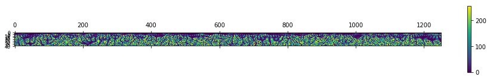

```python
import matplotlib.pyplot as plt
plt.matshow(df_images_final[6,:,:])
plt.yticks(fontsize=8)
plt.colorbar()
plt.show()
```

**Separation in Train/Validation Sets**

```python
y_train_ = pd.read_csv("original_data/y_train.csv").as_matrix()[:, 1].squeeze()
X_train_cnn, X_val_cnn, y_train_cnn, y_val_cnn = train_test_split(df_images_final, y_train_, test_size=0.10,random_state=0, stratify=y_train_)
```

**Reshaping inputs for Keras**

```python
X_train_cnn=X_train_cnn.reshape(X_train_cnn.shape[0],X_train_cnn.shape[1],X_train_cnn.shape[2],1)
X_val_cnn=X_val_cnn.reshape(X_val_cnn.shape[0],X_val_cnn.shape[1],X_val_cnn.shape[2],1)
y_train_cnn = keras.utils.to_categorical(y_train_cnn, num_classes)
y_val_cnn = keras.utils.to_categorical(y_val_cnn, num_classes)
```

```python
import keras
from keras.layers import Dense, Flatten
from keras.layers import Conv2D, MaxPooling2D, BatchNormalization, Dropout
from keras.models import Sequential
from keras.callbacks import History
history = History()

img_x = 40
img_y = 1250
img_z = 1
input_shape = (img_x, img_y, img_z)

num_classes = 3
batch_size = 128
epochs = 2

model = Sequential()

model.add(Conv2D(32, (3, 3), activation='relu', padding='same', input_shape=input_shape))
model.add(Conv2D(32, (3, 3), activation='relu'))
model.add(MaxPooling2D(pool_size=(2, 2)))
model.add(Dropout(0.25))

model.add(Conv2D(64, (3, 5), activation='relu', padding='same'))
model.add(Conv2D(64, (3, 5), activation='relu'))
model.add(MaxPooling2D(pool_size=(2, 2)))
model.add(Dropout(0.25))


model.add(Conv2D(128, (3, 7), activation='relu', padding='same'))
model.add(Conv2D(128, (3, 7), activation='relu'))
model.add(MaxPooling2D(pool_size=(2, 2)))
model.add(Dropout(0.25))

model.add(Flatten())

model.add(Dense(128, activation='relu'))
model.add(Dropout(0.5))

model.add(Dense(128, activation='relu'))
model.add(Dropout(0.5))

model.add(Dense(128, activation='relu'))
model.add(Dropout(0.5))

model.add(Dense(num_classes, activation='softmax'))

model.compile(loss=keras.losses.categorical_crossentropy,
              optimizer=keras.optimizers.Adam(),
              metrics=['accuracy'])


model.fit(X_train_cnn, y_train_cnn,
          batch_size=batch_size,
          epochs=epochs,
          verbose=1,
          validation_data=(X_val_cnn, y_val_cnn),
          callbacks=[history])

train_score = model.evaluate(X_train_cnn, y_train_cnn, verbose=0)
print('Train loss: {}, Train accuracy: {}'.format(train_score[0], train_score[1]))
test_score = model.evaluate(X_val_cnn, y_val_cnn, verbose=0)
print('Test loss: {}, Test accuracy: {}'.format(test_score[0], test_score[1]))
```

[output not shown]

```
Train on 235470 samples, validate on 26164 samples
```

```python
print(model.summary())
```

```
_________________________________________________________________
Layer (type)                 Output Shape              Param #
=================================================================
conv2d_78 (Conv2D)           (None, 40, 1250, 32)      320
_________________________________________________________________
conv2d_79 (Conv2D)           (None, 38, 1248, 32)      9248
_________________________________________________________________
max_pooling2d_41 (MaxPooling (None, 19, 624, 32)       0
_________________________________________________________________
dropout_46 (Dropout)         (None, 19, 624, 32)       0
_________________________________________________________________
conv2d_80 (Conv2D)           (None, 19, 624, 64)       30784
_________________________________________________________________
conv2d_81 (Conv2D)           (None, 17, 620, 64)       61504
_________________________________________________________________
max_pooling2d_42 (MaxPooling (None, 8, 310, 64)        0
_________________________________________________________________
dropout_47 (Dropout)         (None, 8, 310, 64)        0
_________________________________________________________________
conv2d_82 (Conv2D)           (None, 8, 310, 128)       172160
_________________________________________________________________
conv2d_83 (Conv2D)           (None, 6, 304, 128)       344192
_________________________________________________________________
max_pooling2d_43 (MaxPooling (None, 3, 152, 128)       0
_________________________________________________________________
dropout_48 (Dropout)         (None, 3, 152, 128)       0
_________________________________________________________________
flatten_17 (Flatten)         (None, 58368)             0
_________________________________________________________________
dense_33 (Dense)             (None, 128)               7471232
_________________________________________________________________
dropout_49 (Dropout)         (None, 128)               0
_________________________________________________________________
dense_34 (Dense)             (None, 128)               16512
_________________________________________________________________
dropout_50 (Dropout)         (None, 128)               0
_________________________________________________________________
dense_35 (Dense)             (None, 128)               16512
_________________________________________________________________
dropout_51 (Dropout)         (None, 128)               0
_________________________________________________________________
dense_36 (Dense)             (None, 3)                 387
=================================================================
Total params: 8,122,851
Trainable params: 8,122,851
Non-trainable params: 0
_________________________________________________________________
None
```

### g) CNN-1D on raw data (EEG signals only)

```python
y_train = pd.read_csv(root_path + "y_train.csv").as_matrix()[:, 1].squeeze()
X_train = h5py.File(root_path + "X_train.h5", "r")
df_train = pd.DataFrame(data=X_train["features"][:])
X_train_eeg, X_val_eeg, y_train_eeg, y_val_eeg = train_test_split(df_train[selected_var], y_train_, test_size=0.10,random_state=0, stratify=y_train_)
```

```python
from keras.utils import to_categorical

# Convert labels to categorical one-hot encoding
y_train_eeg=pd.DataFrame(y_train_eeg)
y_val_eeg=pd.DataFrame(y_val_eeg)
y_train_eeg = to_categorical(y_train_eeg.values, num_classes=3)
y_val_eeg= to_categorical(y_val_eeg.values, num_classes=3)
```

```python
# we feed 2 downsampled datasets + the original dataset = 3

model_train = [
    X_train_eeg.iloc[:, np.arange(0, 1250, 5)].values[:,:,None], # small
    X_train_eeg.iloc[:, np.arange(0, 1250, 2)].values[:,:,None], # medium
    X_train_eeg.values[:,:,None],                                # original
]

model_val = [
    X_val_eeg.iloc[:, np.arange(0, 1250, 5)].values[:,:,None], # small
    X_val_eeg.iloc[:, np.arange(0, 1250, 2)].values[:,:,None], # medium
    X_val_eeg.values[:,:,None],                                # original
]
```

**Applying a 1D-CNN on the original dataset + 2 downsampled version of the dataset**

```python
from keras.models import Model, Sequential
from keras.layers import Dense, Dropout, Input, Concatenate
from keras.layers import Conv1D, MaxPooling1D, GlobalMaxPooling1D

# Base model
# 3 of them are run in parallel with each a downsampled version of the data
def get_base_model(input_len, kernel_size):
    nb_filters = 20

    model = Sequential([
        Conv1D(nb_filters, kernel_size, activation='relu', input_shape=(input_len, 1)),
        Conv1D(nb_filters, kernel_size, activation='relu'),
        MaxPooling1D(10),
        Conv1D(nb_filters*2, kernel_size, activation='relu'),
        Conv1D(nb_filters*2, kernel_size, activation='relu'),
        GlobalMaxPooling1D(),
        Dense(50, activation='relu'),
        Dense(50, activation='relu'),
        Dropout(0.3),
    ])

    return model

# Main model
def main_model(inputs_lens = [250, 625, 1250], kernel_sizes = [4, 8, 16]):
    # the inputs to the branches are the original time series, and its down-sampled versions
    input_smallseq = Input(shape=(inputs_lens[0], 1), name='eeg_small')
    input_medseq   = Input(shape=(inputs_lens[1], 1), name='eeg_medium')
    input_origseq  = Input(shape=(inputs_lens[2], 1), name='eeg_original')

    # the more down-sampled the time series, the shorter the corresponding filter
    base_net_small    = get_base_model(inputs_lens[0], kernel_sizes[0])
    base_net_med      = get_base_model(inputs_lens[1], kernel_sizes[1])
    base_net_original = get_base_model(inputs_lens[2], kernel_sizes[2])

    embedding_small    = base_net_small(input_smallseq)
    embedding_med      = base_net_med(input_medseq)
    embedding_original = base_net_original(input_origseq)

    # concatenate all the outputs
    merged = Concatenate()([embedding_small, embedding_med, embedding_original])
    dropped = Dropout(0.5)(merged)

    stacked = Dense(64, activation='relu')(dropped)
    stacked = Dense(64, activation='relu')(stacked)


    # output layer
    out = Dense(3, activation='softmax')(stacked)

    model = Model(inputs=[input_smallseq, input_medseq, input_origseq], outputs=out)
    return model
```

```python
batch_size = 256
epochs = 3

model = main_model()

model.compile(loss='categorical_crossentropy',
              optimizer='adam',
              metrics=['accuracy'])

model.fit(model_train, y_train_eeg,
          batch_size=batch_size,
          epochs=epochs,
          validation_data=(model_val, y_val_eeg))
```

```
Train on 235470 samples, validate on 26164 samples
```

```
<keras.callbacks.callbacks.History at 0x27814da1e80>
```

```python
print(model.summary())
```

```
Model: "model_7"
__________________________________________________________________________________________________
Layer (type)                    Output Shape         Param #     Connected to
==================================================================================================
eeg_small (InputLayer)          (None, 250, 1)       0
__________________________________________________________________________________________________
eeg_medium (InputLayer)         (None, 625, 1)       0
__________________________________________________________________________________________________
eeg_original (InputLayer)       (None, 1250, 1)      0
__________________________________________________________________________________________________
sequential_22 (Sequential)      (None, 50)           16000       eeg_small[0][0]
__________________________________________________________________________________________________
sequential_23 (Sequential)      (None, 50)           27280       eeg_medium[0][0]
__________________________________________________________________________________________________
sequential_24 (Sequential)      (None, 50)           49840       eeg_original[0][0]
__________________________________________________________________________________________________
concatenate_12 (Concatenate)    (None, 150)          0           sequential_22[1][0]
                                                                 sequential_23[1][0]
                                                                 sequential_24[1][0]
__________________________________________________________________________________________________
dropout_32 (Dropout)            (None, 150)          0           concatenate_12[0][0]
__________________________________________________________________________________________________
dense_50 (Dense)                (None, 64)           9664        dropout_32[0][0]
__________________________________________________________________________________________________
dense_51 (Dense)                (None, 64)           4160        dense_50[0][0]
__________________________________________________________________________________________________
dense_52 (Dense)                (None, 3)            195         dense_51[0][0]
==================================================================================================
Total params: 107,139
Trainable params: 107,139
Non-trainable params: 0
__________________________________________________________________________________________________
None
```